# Restaurant Visitor Forecasting Project

February 11, 2018

## 1. Introduction

- Predict the total number of visitors.
- The eight (8) data files are listed below:
  - air_reserve.csv
  - hpg_reserve.csv
  - air_store_info.csv
  - hpg_store_info.csv
  - store_id_relation.csv
  - air_visit_data.csv
  - sample_submission.csv
  - date_info.csv

For our purposes, we only used air_visit_data.csv and data_info.csv files.

## 2. Data Overview

Summary Statistic: Air Visit Data

|  | unique_store_id | air_store_id | visit_date | visitors |
| --- | --- | --- | --- | --- |
|  | 829 | Length:252108 | Min. :2016-01-01 | Min. : 1.00 |
|  |  | Class :character | 1st Qu.:2016-07-23 | 1st Qu.: 9.00 |
|  |  | Mode :character | Median :2016-10-23 | Median : 17.00 |
|  |  |  | Mean :2016-10-12 | Mean : 20.97 |
|  |  |  | 3rd Qu.:2017-01-24 | 3rd Qu.: 29.00 |
|  |  |  | Max. :2017-04-22 | Max. :877.00 |

## 2. Data Overview (cont'd)

Data Structure: Air visit data with first three values

| variable | class | first_values |
| --- | --- | --- |
| air_store_id | character | air_ba937bf13d40fb24, air_ba937bf13d40fb24, air_ba937bf13d40fb24 |
| visit_date | date | 2016-01-13, 2016-01-14, 2016-01-15 |
| visitors | integer | 25, 32, 29 |

## 2. Data Overview (cont'd)

Summary Statistic: Holiday Data

|  | calendar_date | day_of_week | holiday_flg |
| --- | --- | --- | --- |
|  | Min. :2016-01-01 | Length:517 | Min. :0.0000 |
|  | 1st Qu.:2016-05-09 | Class :character | 1st Qu.:0.0000 |
|  | Median :2016-09-15 | Mode :character | Median :0.0000 |
|  | Mean :2016-09-15 |  | Mean :0.0677 |
|  | 3rd Qu.:2017-01-22 |  | 3rd Qu.:0.0000 |
|  | Max. :2017-05-31 |  | Max. :1.0000 |

## 2. Data Overview (cont'd)

Summary Statistic for first ten Store

|  | NAs | Minimum | Maximum | 1. Quartile | 3. Quartile | Mean | Median |
| --- | --- | --- | --- | --- | --- | --- | --- |
| air_00a91d42b08b08d9 | 246 | 1 | 99 | 18.00 | 34 | 26.081897 | 26 |
| air_0164b9927d20bcc3 | 329 | 1 | 27 | 4.00 | 12 | 9.248322 | 8 |
| air_0241aa3964b7f861 | 82 | 1 | 48 | 6.00 | 13 | 9.896465 | 9 |
| air_0328696196e46f18 | 362 | 1 | 41 | 4.00 | 10 | 7.939655 | 6 |
| air_034a3d5b40d5b1b1 | 227 | 1 | 116 | 6.00 | 20 | 14.828685 | 12 |
| air_036d4f1ee7285390 | 197 | 4 | 188 | 14.00 | 29 | 22.455516 | 21 |
| air_0382c794b73b51ad | 180 | 1 | 74 | 18.00 | 30 | 23.687919 | 23 |
| air_03963426c9312048 | 49 | 2 | 119 | 20.00 | 58 | 39.340326 | 36 |
| air_04341b588bde96cd | 6 | 1 | 119 | 24.75 | 47 | 35.870763 | 34 |
| air_049f6d5b402a31b2 | 220 | 1 | 29 | 6.00 | 16 | 11.531008 | 11 |

## 3. Data Visualizations - Air Visit Data

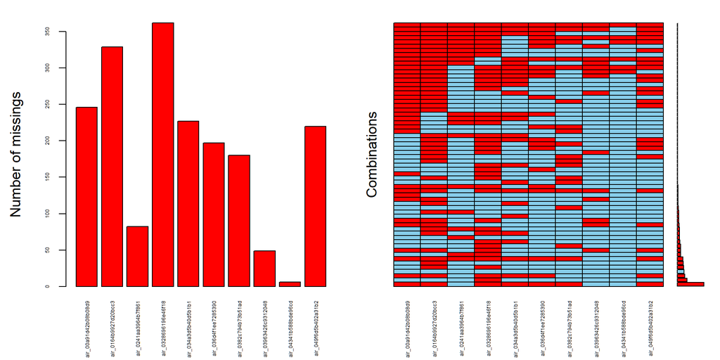

## 3. Data Visualizations - Air Visit (cont'd)

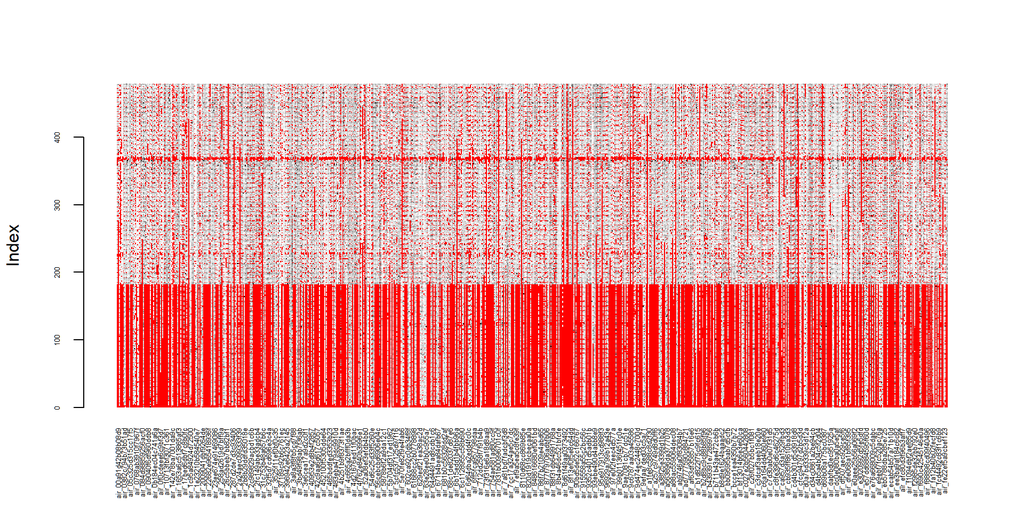

## 3. Data Visualizations - Air Visit (cont'd)

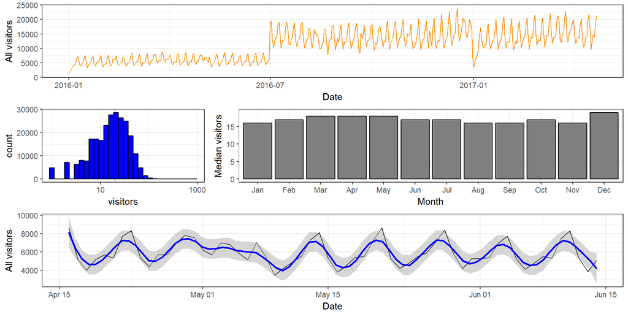

## 4. Data Visualizations - Holiday Data

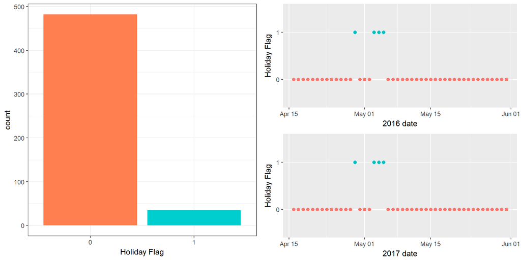

## 5. Data Preparation

- Approach 1:
  - Formatted the initial air visit data so all the stores appear in each individual columns.
  - Removed those 8 stores that are not part of the test set.
  - Added the date info (holiday) data to our initial dataset.
  - Replaced all the NAs, prior to the first value, with zero (0) for each store.
  - Replaced all NAs with zero (0) occurring every 7th day.
    - We assumed that if NA is consistent every 7th day from the first value, it means that the store is closed that day every week.
  - Replaced all NAs with zero if those days fall on a holiday.
  - Replaced all NAs with mean, median, linear, and exponential imputation.
  - Converted the dataset into a time series (Each imputed dataset converted into time series data).

## 5. Data Preparation (cont'd)

- Approach 3:
  - Formatted the initial air visit data so all the stores appear in each individual columns.
  - Removed those 8 stores that are not part of the test set.
  - Added the date info (holiday) data to our initial dataset.
  - Replaced all NAs with zero (0) occurring every 7th day.
    - We assumed that if NA is consistent every 7th day from the first value, it means that the store is closed that day every week.
  - Replaced all NAs with zero if those days fall on a holiday.
  - Replaced all NAs with median imputation.
  - Fix the outliers in the data from the first value to the last record.
  - Converted the dataset into a time series.
  - Split the training data further into training and test dataset with 70/30 split approach.

## 6. Forecasting Methods - Model: Approach 1

**Approach 1 Kaggle Submission Results:**

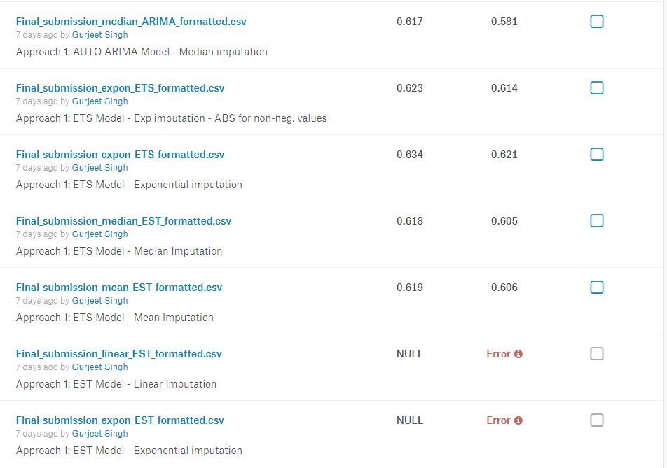

## 6. Forecasting Methods - Model: Approach 2

**Approach 2 Kaggle Submission Results:**

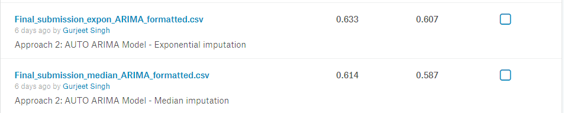

## 6. Forecasting Methods - Model: Approach 3

**Approach 3 Kaggle Submission Results:**

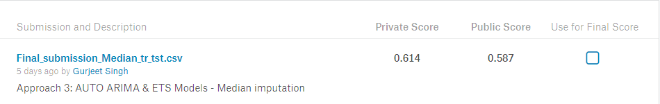

## 7. Literature

1. Building Forecasting Models for Restaurant Owners and Managers: A Case Study
2. Data Mining on Time Series
3. Forecasting Restaurant Sales Using Multiple Regression and Box-Jenkins Analysis
4. A Hybrid Seasonal Autoregressive
5. Time-Series Forecasting: Food-Service Industry

## 8. Limitations

- Lack of knowledge of building models with data of multiple time-series
- Heavily reliance on auto.arima and ets methods.
- Excessive iterations for building forecasting models.

## 9. Future Work

Plan to improve my models in future by taking the following steps:

1. Use the Last Observation Carried Forward approach (na.locf function from the imputeTS package) for imputation.
2. For each time series (for each restaurant) model, capture the MASE in a variable. Take the average of the MASE and then compare the value with other models. The model that has the best average MASE value, use that as the final model.
3. Use other forecasting methods such as Prophet, Box-Jenkins, SARIMA, SARIMAX, and Quantile Regression.
4. Lastly, use “DoParallel” in future.

## 10. Learnings

- Great learning experience.
- Exposure on how to work with the multiple time series data.
- Experience with Kaggle competition.
- Great discussion with classmates.
- Got introduced to new R-Packages such as lubridate, VIM, and imputeTS.

## 11. References

Kaggle Kernels and Discussion boards: (https://www.kaggle.com/c/recruit-restaurant-visitor-forecasting)

Missing Values Visualization: (http://rstudio-pubs-static.s3.amazonaws.com/4625_fa990d611f024ea69e7e2b10dd228fe7.html)